# Prevendo Demandas de Estoque com Base em Vendas

Luiz Fernando Mello

28/06/2021

# Inicio do script e Análise Exploratória

Definindo o local de trabalho

```r
setwd("C:/repos/Projeto02_PrevendoDemandaDeEstoqueComBaseEmVendas")
```

Carregar pacote e dataset utilizado no script

```r
library(data.table)
library(moments)

vendas <- fread("Datasets/train.csv", header = TRUE,
                   sep = ",", stringsAsFactors = FALSE, encoding = "UTF-8")
```

O conjunto de dados carregado é muito grande, para não ter problemas com capacidade computacional posteriormente, vamos dividir o dataset.

```r
set.seed(357951)
indexes <- sample.int(nrow(vendas), 500000)
vendas <- vendas[indexes,]
rm(indexes)
```

Adicionar variável ID para auxiliar na remoção de outliers posteriormente

```r
vendas$id <- 1:nrow(vendas)
```

Visualizar as variáveis e tipos de dados do dataset.

```r
str(vendas)
```

```
## Classes 'data.table' and 'data.frame':   500000 obs. of  12 variables:
##  $ Semana           : int  5 6 6 6 7 5 3 9 8 4 ...
##  $ Agencia_ID       : int  1384 1217 2019 1475 1117 1346 2019 4010 2213 1346 ...
##  $ Canal_ID         : int  1 1 1 4 1 1 1 1 1 1 ...
##  $ Ruta_SAK         : int  2821 1139 1208 4705 1619 2012 2814 1186 1010 2113 ...
##  $ Cliente_ID       : int  2313730 657553 2068541 4672763 350487 1418837 2104100 1443611 4372082 409047 ...
##  $ Producto_ID      : int  36610 1238 1240 37058 9217 32302 30532 43206 35727 30532 ...
##  $ Venta_uni_hoy    : int  80 2 4 45 2 6 4 18 19 5 ...
##  $ Venta_hoy        : num  61.6 19.7 33.5 341.1 18 ...
##  $ Dev_uni_proxima  : int  0 0 0 0 1 0 0 0 0 0 ...
##  $ Dev_proxima      : num  0 0 0 0 9 0 0 0 0 0 ...
##  $ Demanda_uni_equil: int  80 2 4 45 1 6 4 18 19 5 ...
##  $ id               : int  1 2 3 4 5 6 7 8 9 10 ...
##  - attr(*, ".internal.selfref")=<externalptr>
```

Verificar se contem algum valor faltante

```r
any(is.na(vendas))
```

```
## [1] FALSE
```

Resultado: Não contem nenhum valor faltante no dataset.

## Análise de variáveis numéricas

Definindo as variáveis numéricas do dataset

```r
variaveis_numericas <- c("Venta_uni_hoy", "Venta_hoy",
                         "Dev_uni_proxima", "Dev_proxima", "Demanda_uni_equil")
```

### Medidas de tendência central e dispersão das variáveis

```
## Medidas da variável Venta_uni_hoy:
##     Min.  1st Qu.   Median     Mean  3rd Qu.     Max.
##    0.000    2.000    3.000    7.319    7.000 4606.000
## Desvio padrão: 23.2857251253615
```

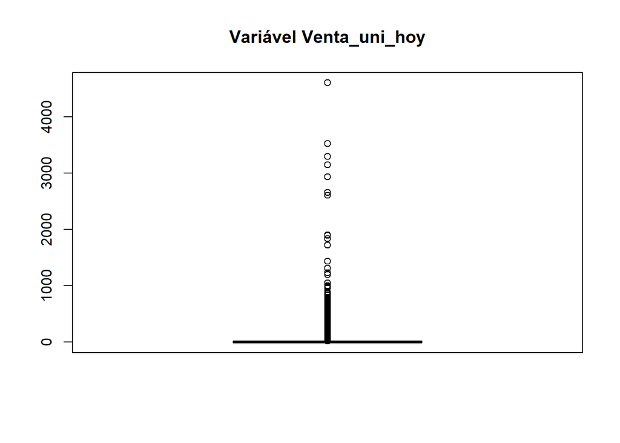

```
## Medidas da variável Venta_hoy:
##     Min.  1st Qu.   Median     Mean  3rd Qu.     Max.
##     0.00    16.76    30.00    68.93    56.10 76000.00
## Desvio padrão: 340.054654157467
```

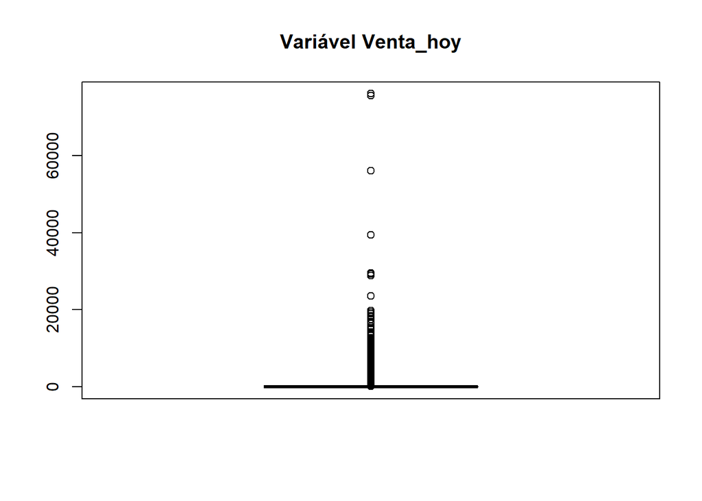

```
## Medidas da variável Dev_uni_proxima:
##      Min.   1st Qu.    Median      Mean   3rd Qu.      Max.
##    0.0000    0.0000    0.0000    0.1332    0.0000 1100.0000
## Desvio padrão: 3.0218155949586
```

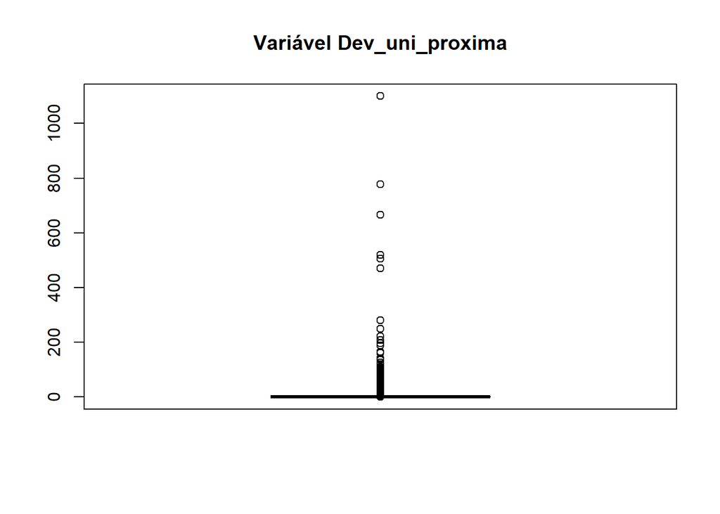

```
## Medidas da variável Dev_proxima:
##     Min.  1st Qu.   Median     Mean  3rd Qu.     Max.
##    0.000    0.000    0.000    1.269    0.000 7546.000
## Desvio padrão: 24.0509938699455
```

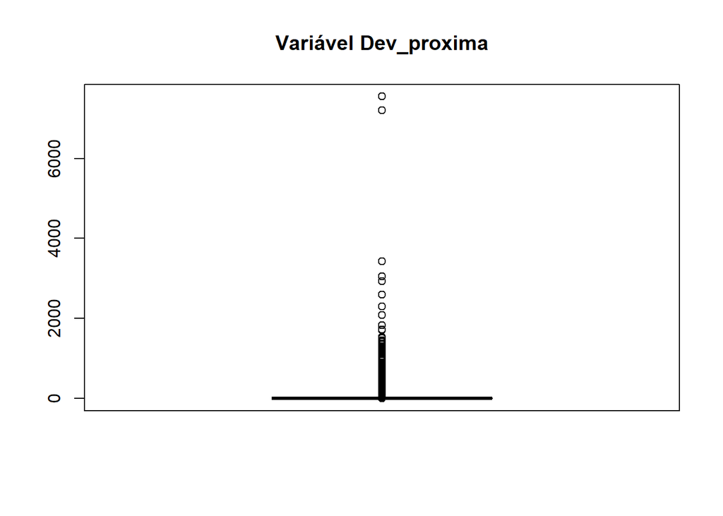

```
## Medidas da variável Demanda_uni_equil:
##     Min.  1st Qu.   Median     Mean  3rd Qu.     Max.
##    0.000    2.000    3.000    7.233    6.000 4606.000
## Desvio padrão: 23.1684561272675
```

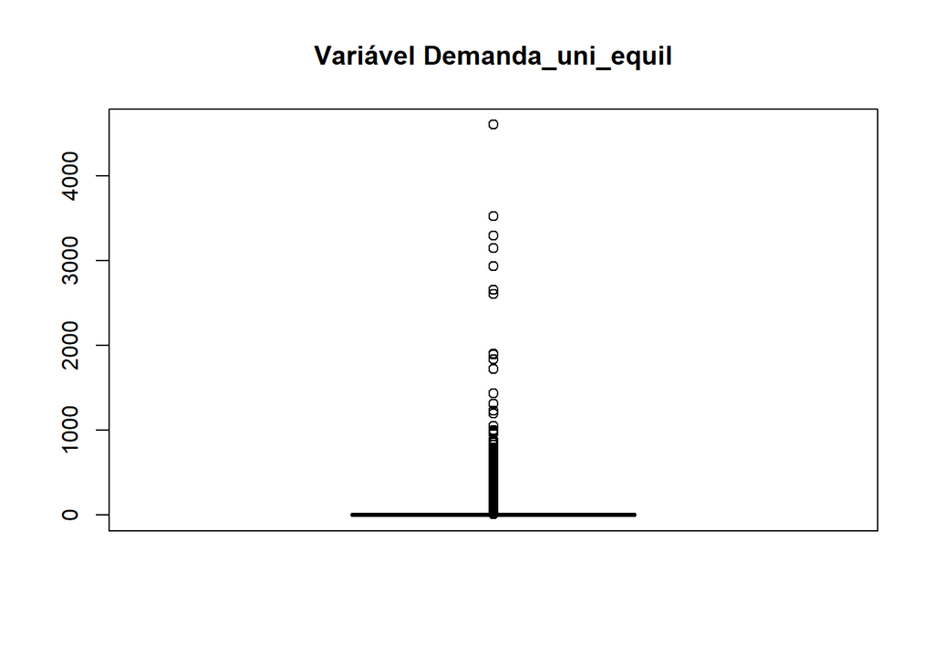

```r
for( i in variaveis_numericas) {
  cat(paste("Medidas da variável ", i, ":", "\n", sep = ""))
  print(summary(vendas[[i]]))
  cat(paste("Desvio padrão:", sd(vendas[[i]])))
  cat("\n\n")
  boxplot(vendas[[i]], main = paste("Variável", i))
}
```

Resultado: Variáveis não estão em uma distribuição normal e contem muitos outliers

### Análise de correlação entre as variáveis

```r
cor(vendas$Venta_uni_hoy, vendas$Venta_hoy)
```

```
## [1] 0.7649191
```

Resultado: As variáveis Venta, tem uma boa correlação positiva

```r
cor(vendas$Dev_uni_proxima, vendas$Dev_proxima)
```

```
## [1] 0.849129
```

Resultado: As variáveis Dev, tem uma boa correlação positiva

```r
cor(vendas$Venta_uni_hoy, vendas$Demanda_uni_equil)
```

```
## [1] 0.998865
```

Resultado: Variável venta_uni_hoy, tem uma forte correlação positiva com a variável target

```r
cor(vendas$Venta_hoy, vendas$Demanda_uni_equil)
```

```
## [1] 0.7640993
```

```r
cor(vendas$Dev_uni_proxima, vendas$Demanda_uni_equil)
```

```
## [1] 0.02514556
```

Resultado: Variável dev_uni_proxima, tem uma pequena correlação positiva com a variável target

```r
cor(vendas$Dev_proxima, vendas$Demanda_uni_equil)
```

```
## [1] 0.0400119
```

Resultado: Variável dev_proxima, tem uma pequena correlação positiva com a variável target

### Análise de simetria das variáveis

```r
for(i in variaveis_numericas) {
  cat(paste("Simetria da variável ", i, ":", "\n", sep = ""))
  print(skewness(vendas[[i]]))
  cat("\n")
}
```

```
## Simetria da variável Venta_uni_hoy:
## [1] 56.55864
##
## Simetria da variável Venta_hoy:
## [1] 74.71935
##
## Simetria da variável Dev_uni_proxima:
## [1] 190.1445
##
## Simetria da variável Dev_proxima:
## [1] 149.6896
##
## Simetria da variável Demanda_uni_equil:
## [1] 57.27351
```

Resultado: Todas as variáveis numéricas do dataset são assimetrica positiva.

### Análise de valores duplicados

```r
for(i in variaveis_numericas) {
  cat(paste("Valores duplicados da variável ", i, ":", "\n", sep = ""))
  print(sum(duplicated(vendas[[i]])))
  cat("\n")
}
```

```
## Valores duplicados da variável Venta_uni_hoy:
## [1] 499487
##
## Valores duplicados da variável Venta_hoy:
## [1] 489496
##
## Valores duplicados da variável Dev_uni_proxima:
## [1] 499890
##
## Valores duplicados da variável Dev_proxima:
## [1] 498200
##
## Valores duplicados da variável Demanda_uni_equil:
## [1] 499484
```

### Identificando outliers de cada variável

```r
datasets_outliers <- data.frame()
for(i in variaveis_numericas) {
  cat(paste("Outliers da variável ", i, ":", "\n", sep = ""))
  metrica = mean(vendas[[i]]) + (sd(vendas[[i]]) * 2)
  dataset <- subset(vendas, vendas[[i]] > metrica)
  datasets_outliers <- rbind(datasets_outliers, dataset)
  print( nrow(dataset) )
  datasets_outliers <- unique(datasets_outliers)
  rm(dataset)
  rm(metrica)
  cat("\n")
}
```

```
## Outliers da variável Venta_uni_hoy:
## [1] 6439
##
## Outliers da variável Venta_hoy:
## [1] 4289
##
## Outliers da variável Dev_uni_proxima:
## [1] 1756
##
## Outliers da variável Dev_proxima:
## [1] 2299
##
## Outliers da variável Demanda_uni_equil:
## [1] 6349
```

```r
rm(i)
```

#### Porcentagem de outliers dentro do dataset

```r
print( paste("O dataset tem ", round((nrow(datasets_outliers)/nrow(vendas)*100), 2), "% de outliers", sep = "" ))
```

```
## [1] "O dataset tem 1.9% de outliers"
```

Resultado: Os valores outliers estão no dataframe “datasets_outliers”, vai ser utilizado para remover os outliers na manipulação de dados.